# Fitted-Model-Based Annotations

## stat_quant_eq(), stat_quant_line() and stat_quant_band()

Package ‘quantreg’ implements quantile regression for multiple types of models: linear models with function `quantreg::rq()`, non-linear models with function `quantreg::nlreg()`, and additive models with function `quantreg::rqss()`. Each of these functions supports different methods of estimation which can be passed through parameter `method.args` or more easily using a character string such as `"rq:br"` argument to parameter `method` of the statistic, where `quantreg::rq()` is the model fit function and `"br"` the argument passed to the `method` parameter of `quantreg::rq()`. As with the statistics for polynomials described in the previous section, all the statistics described in the current section support linear models while `stat_quant_line()` and `stat_quant_band()` also support additive models. (Support for `quantreg::nlreg()` is not yet implemented.)

In the case of quantile regression it is frequently the case that multiple quantile regressions are fitted simultaneously. This case is not supported by `stat_poly_eq()` but instead by `stat_quant_eq()`. This statistics is similar to `stat_poly_eq()` both in behaviour and parameters. It supports quantile regression of *y* on *x* or *x* on *y* fitted with function `quantreg::rq`.

The statistic `stat_quant_line()` is substitute for `ggplot2::stat_quantile()` with enhancements. It adds a layer similar to that created by `stat_poly_line()` including confidence bands for quantile regression, by default for *p* = 0.95. It has the an interface and default arguments consitant with `stat_quant_eq()`, and supports both *x* and *y* as explanatory variable in `formula` and also `orientation`. Confidence intervals for the fits to individual quantiles fulfil the same purpose as in OLS fits: providing a boundary for the *estimated line* computed for each individual quantile. They are not shown by default, unless a single quantile is passed as argument, but can be enabled with `se = TRUE` and disabled with `se = FALSE`.

The statistic `stat_quant_band()` creates a line plus band plot that is, with the quantiles used by default similar to a boxplot in its interpretation. In this case, the band informs about the local spread of the *observations* in the same way as the box in box plots does. Which three quantiles are used can be set through parameter `quantiles` but in contrast to `stat_quant_line()` and `stat_quant_eq()` only a vector of three quantiles is accepted.

Similarly to `ggplot2::stat_quantiles()`, `stat_quant_eq()` and `stat_quant_line()` accept a `numeric` vector as argument to `quantiles` and output one equation or one line per group and quantile. Statistic `stat_quant_eq()` also returns variable `grp.label` containing by default a character string indicating the value of the quantile, and if a variable is mapped to the pseudo aesthetic `grp.label`, its value is prepended to the quantiles.

With default quantiles, 0.25, 0.50, 0.75, equivalent to those used for the box of box plots, a plot with a line for median regression and a band highlighting the space between the quartiles is plotted.

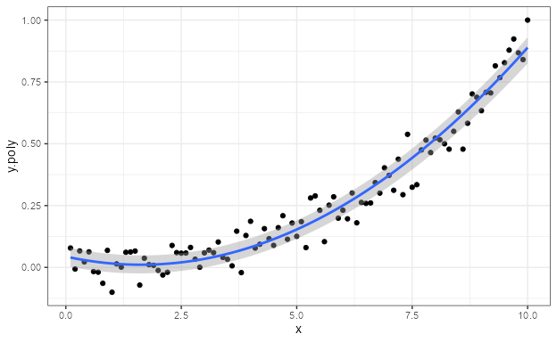

```r
ggplot(my.data, aes(x, y.poly)) +
  geom_point() +
  stat_quant_band(formula = y ~ poly(x, 2))
```

Overriding the values for `quantiles` we find a boundary containing 90% of the observations. We add the observations as points after the lines so that points are plotted on top of the lines.

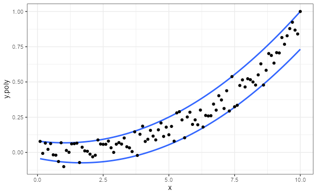

```r
ggplot(my.data, aes(x, y.poly)) +
  stat_quant_line(formula = y ~ poly(x, 2),
                  quantiles = c(0.05, 0.95)) +
  geom_point()
```

A line for the quantile regression plus a confidence band for it is the default for a single quantile.

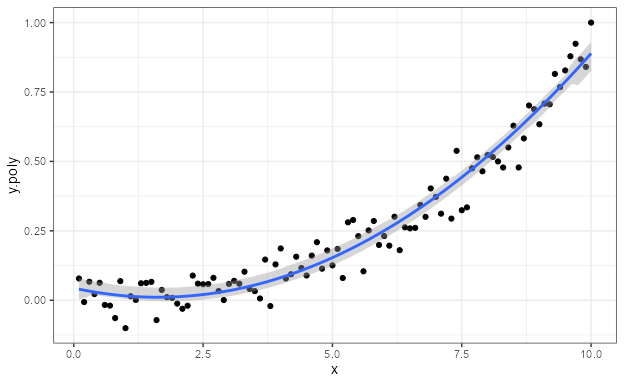

```r
ggplot(my.data, aes(x, y.poly)) +
  geom_point() +
  stat_quant_line(formula = y ~ poly(x, 2),
                  quantiles = 0.5)
```

`stat_quant_eq()` assembles the fitted equations that are combined and mapped to the `label` aesthetic using `f_use_label()`. A message at the R console shows the short names of the formatted character strings available for use in `use_label()` or `f_use_label()` as:

```
'stat_quant_eq' labels (3 rows): eq, AIC, rho, n, grp, qtl, method.
```

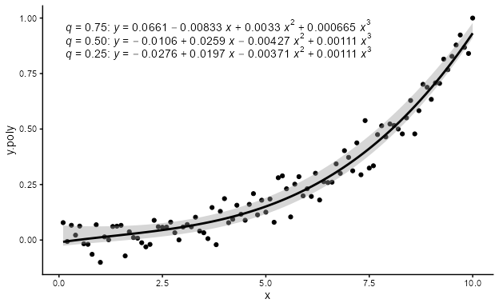

```r
ggplot(my.data, aes(x, y.poly)) +
  geom_point() +
  stat_quant_band(formula = formula,
                  color = "black",
                  fill = "grey60") +
  stat_quant_eq(f_use_label("qtl", "eq", format = "%s*\": \"*%s"),
                formula = formula) +
  theme_classic()
```

Grouping and faceting are supported by `stat_quant_eq()`, `stat_quant_line()` and `stat_quant_band()` as described above for the other statistics described above. The main difference is that for each data group more than one model can be fit with one prediction line and one equation for each model. The positions are as in other cases computed automatically or set manually.

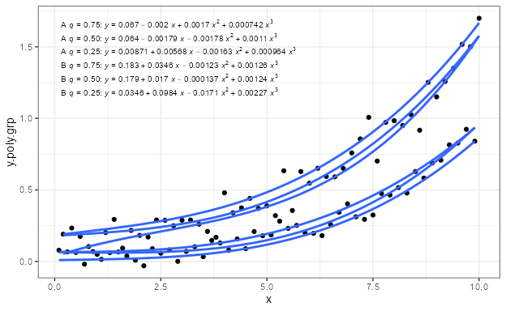

```r
ggplot(my.data,
       aes(x, y.poly.grp, group = group, grp.label = group)) +
  geom_point() +
  stat_quant_line(formula = formula) +
  stat_quant_eq(f_use_label("grp", "qtl", "eq",
                            format = "%s*\" \"*%s*\": \"*%s"),
                size = 2.7,
                formula = formula)
```

Grouping can be combined with a group label by mapping in `aes()` a character variable to `grp.label`.

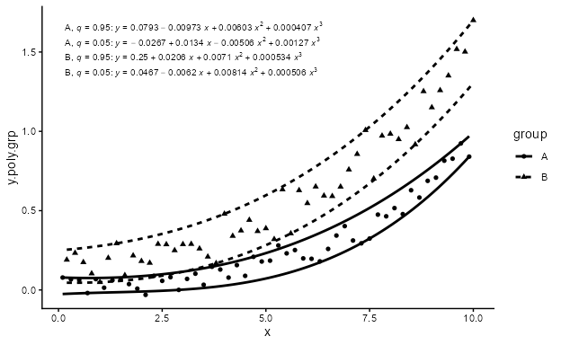

```r
ggplot(my.data,
       aes(x, y.poly.grp, group = group, linetype = group,
           shape = group, grp.label = group)) +
  geom_point() +
  stat_quant_line(formula = formula,
                  quantiles = c(0.05, 0.95),
                  color = "black") +
  stat_quant_eq(aes(label =
                      after_stat(
                        paste(grp.label, "*\", \"*",
                              qtl.label, "*\": \"*",
                              eq.label,
                              sep = ""))),
                size = 2.7,
                formula = formula,
                quantiles = c(0.05, 0.95)) +
  theme_classic()
```

In some cases *double quantile regression* is an informative method to assess reciprocal constraints. For this a fit of *x* on *y* and one of *y* on *x* in the same plot are computed for a large quantile. As is the case for model fitting functions themselves this is simply indicated by the model passed as argument to `formula`, or consistently with `ggplot2::stat_smooth()` through parameter `orientation`.

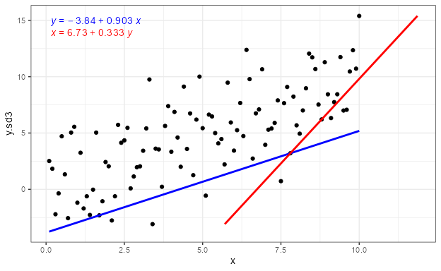

```r
ggplot(my.data, aes(x, y.sd3)) +
  geom_point() +
  stat_quant_line(formula = y ~ x,
                  color = "blue",
                  quantiles = 0.05,
                  se = FALSE) +
  stat_quant_eq(mapping = use_label("eq"),
                formula = y ~ x,
                color = "blue",
                quantiles = 0.05) +
  stat_quant_line(formula = x ~ y,
                  color = "red",
                  quantiles = 0.95,
                  se = FALSE) +
  stat_quant_eq(mapping = use_label("eq"),
                formula = x ~ y,
                color = "red",
                quantiles = 0.95,
                label.y = 0.9)
```

Please, see examples in the previous sections, as they can be adapted. Examples of the use of `stat_quant_line()`, `stat_quant_band()` and `stat_quant_eq()` with other model fitting functions and formulas are available as articles at [the ‘ggpmisc’ web site](https://docs.r4photobiology.info/ggpmisc/).

## stat_distrmix_eq(), stat_distrmix_line() and stat_distrmix_area()

Package ‘mixtools’ implements the fitting of univariate mixture models. Currently, ‘ggpmisc’ only supports fitting of mixtures of univariate Normals with function `normalmixEM()`. Fitting of a single Normal distribution is also supported. The fit is done numerically based on maximum likelihood with an EM or ECM algorithm.

In the case of density distributions the position of quantiles, especially near the tails is a frequent addition to plots. These positions are computed in `stat_distrmix_line()` and `stat_distrmix_area()` from the cumulated density (CDF) both for the mix and for the individual components. The DF, the CDF and positions of quantiles are all returned.

In all cases the distributions are extended to encompass their whole range. The returned data cover With the default `fullrange = TRUE` this whole range, possibly extended to the limits of the scale if broader. In contrast, with `fullrange = FALSE` the distributions are trimmed to the range of the data.

Messages listing the available variables and labels are issued to the R console in interactive R sessions. In this case:

```
'stat_distrmix_line' variables (600 rows): x, component, density, quant.splits, flipped_aes.
'stat_distrmix_eq' labels (1 rows): eq, n, method.
```

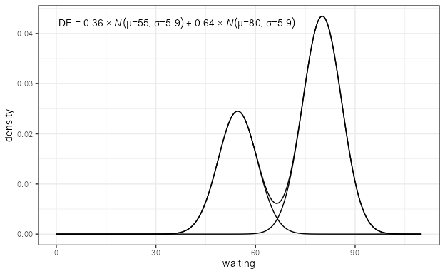

```r
ggplot(faithful, aes(x = waiting)) +
   stat_distrmix_line() +
   stat_distrmix_eq() +
  scale_x_continuous(limits = c(0, 110))
```

Orientation is set automatically based on the mapping of the data to the `x` or the `y` aesthetic.

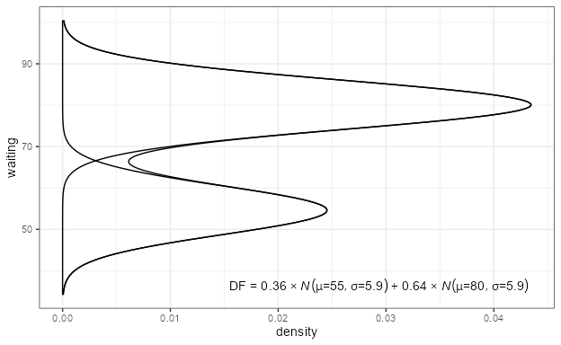

```r
ggplot(faithful, aes(y = waiting)) +
   stat_distrmix_line() +
   stat_distrmix_eq(label.x = "right", label.y = "bottom")
```

The default for `stat_distrmix_line()` is to return densities for components and their sum, below only the sum is returned. With `"members"` only the components would have been returned.

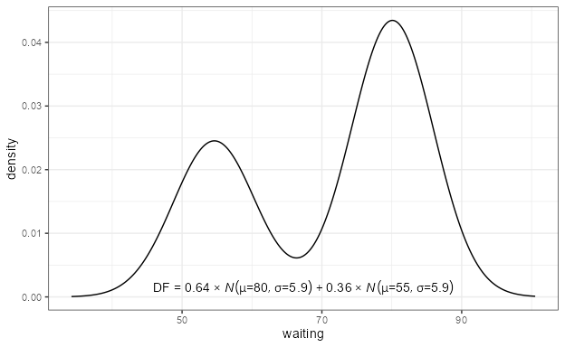

```r
ggplot(faithful, aes(x = waiting)) +
   stat_distrmix_line(components = "sum") +
   stat_distrmix_eq(label.x = "middle", label.y = "bottom")
```

`stat_distrmix_area()` returns by default only the sum of the components and plots it with `geom_area()`.

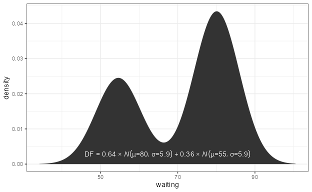

```r
 ggplot(faithful, aes(x = waiting)) +
   stat_distrmix_area() +
   stat_distrmix_eq(colour = "white",
                    label.x = "middle", label.y = 0.08)
```

The position of the quantiles can be highlighted in a single plot layer by mapping the returned integer variable `quant.splits` to the `fill` aesthetic.

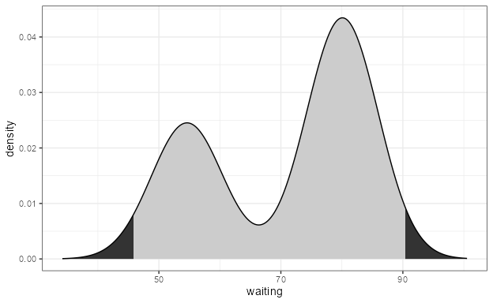

```r
 ggplot(faithful, aes(x = waiting)) +
   stat_distrmix_area(aes(fill = after_stat(quant.splits != 2)),
                      colour = "black", outline.type = "upper",
                      quantiles = c(0.025, 0.975),
                      show.legend = FALSE) +
  scale_fill_manual(values = c("grey80", "grey20"))
```

## stat_multcomp

Multiple comparisons are frequently used when the effect of different levels of a factor are individually of interest. Function `stat_multcomp()` computes adjusted *P*-values for pairwise comparison using Tukey or Dunnet contrasts with function `glht()` from package ‘multcomp’.

The default is Tukey contrasts (all pairs) using Tukey’s HSD (honestly significant difference) approach. The message displayed at the R console is:

```
'stat_multcomp' available labels (6 rows): stars, P, delta, t, default.
```

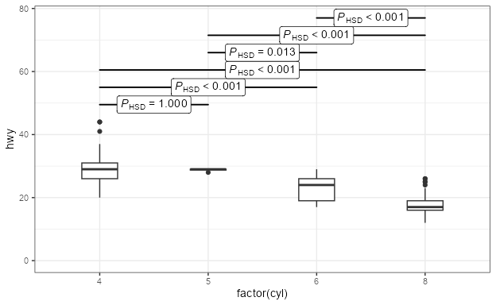

```r
ggplot(mpg, aes(factor(cyl), hwy)) +
  geom_boxplot(width = 0.33)  +
  stat_multcomp() +
  expand_limits(y = 0)
```

To complement the examples in the documentation of the function, below are examples that override several defaults.

Alternatives to the default “tag” values used to describe the adjustment method can be obtained with arguments passed to parameter `adj.method.tag`. In the first example the abbreviation is three characters long, instead of the default of four.

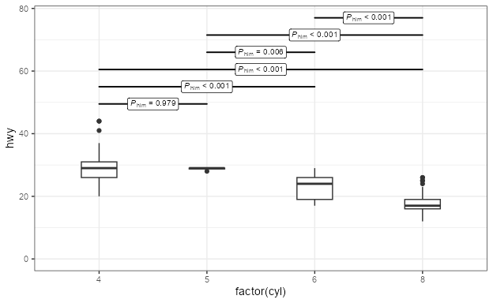

```r
# position of contrasts' bars (manual)
ggplot(mpg, aes(factor(cyl), hwy)) +
  geom_boxplot(width = 0.33)  +
  stat_multcomp(p.adjust.method = "holm",
                adj.method.tag = 3,
                size = 2.75) +
  expand_limits(y = 0)
```

Here we use a negative value to use an abbreviation of the word “adjusted” to three characters.

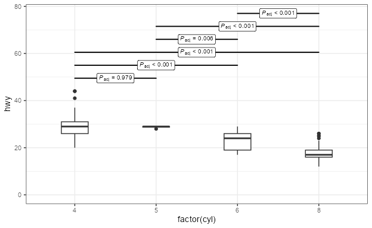

```r
# position of contrasts' bars (manual)
ggplot(mpg, aes(factor(cyl), hwy)) +
  geom_boxplot(width = 0.33)  +
  stat_multcomp(p.adjust.method = "holm",
                adj.method.tag = -3,
                size = 2.75) +
  expand_limits(y = 0)
```

A character string passed as argument is used as is, here to set the tag in Spanish.

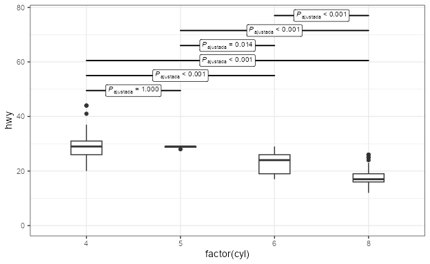

```r
# position of contrasts' bars (manual)
ggplot(mpg, aes(factor(cyl), hwy)) +
  geom_boxplot(width = 0.33)  +
  stat_multcomp(adj.method.tag = "ajustada",
                size = 2.75) +
  expand_limits(y = 0)
```

A numeric vector passed to `label.y` can be used to manually set the location of each label along the *y* axis.

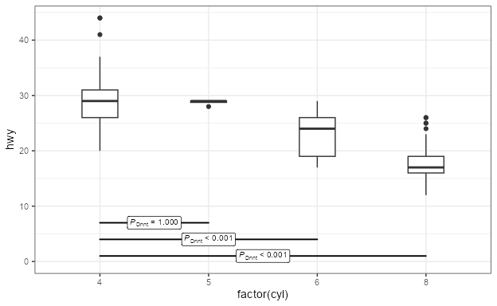

```r
# position of contrasts' bars (manual)
ggplot(mpg, aes(factor(cyl), hwy)) +
  geom_boxplot(width = 0.33)  +
  stat_multcomp(label.y = c(7, 4, 1),
                contrasts = "Dunnet",
                size = 2.75) +
  expand_limits(y = 0)
```

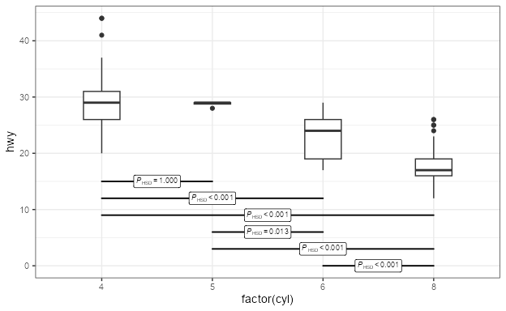

```r
ggplot(mpg, aes(factor(cyl), hwy)) +
  geom_boxplot(width = 0.33) +
   stat_multcomp(label.y =
                   seq(from = 15,
                       by = -3,
                       length.out = 6),
                 size = 2.5) +
   expand_limits(y = 0)
```

We can pre-compute the numeric vector to achieve special positioning, in this case, next to each observation.

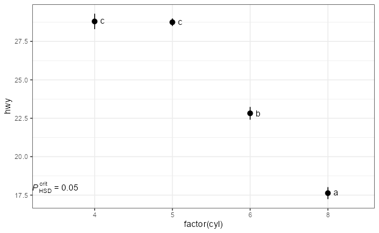

```r
means <-
  aggregate(mpg$hwy,
            by = list(mpg$cyl),
            FUN = mean,
            na.rm = TRUE)[["x"]]

ggplot(mpg, aes(factor(cyl), hwy)) +
  stat_summary(fun.data = mean_se) +
  stat_multcomp(label.type = "letters",
                label.y = c(18, means), # 18 is for critical P label
                position = position_nudge(x = 0.1))
```

We can override the default use of `geom_text()` and also remove the *P* critical label.

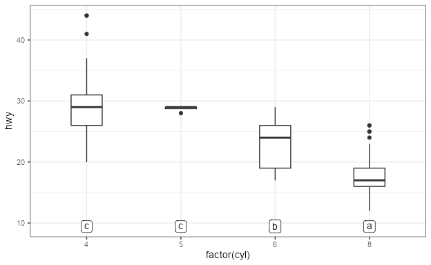

```r
# Using other geometries
ggplot(mpg, aes(factor(cyl), hwy)) +
  geom_boxplot(width = 0.33) +
  stat_multcomp(label.type = "letters",
                adj.method.tag = FALSE,
                geom = "label")
```

Orientation is set automatically based on the mapping of a factor to either the *x* or *y* aesthetic. *Currently, `label.type = "bars"` is not supported in flipped plots like this one.*

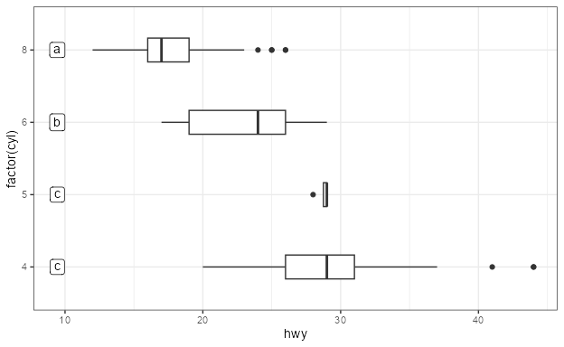

```r
# Using other geometries
ggplot(mpg, aes(hwy, factor(cyl))) +
  geom_boxplot(width = 0.33) +
  stat_multcomp(label.type = "letters",
                adj.method.tag = FALSE,
                geom = "label")
```

With Dunnet contrasts, the use of bars can clutter a plot, and we can alternatively show the outcome for each level that has been compared to a control, the first level.

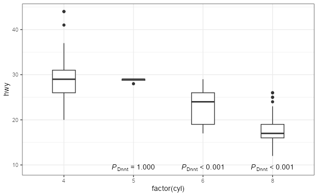

```r
ggplot(mpg, aes(factor(cyl), hwy)) +
  geom_boxplot(width = 0.33) +
  stat_multcomp(aes(x = stage(start = factor(cyl),
                              after_stat = xmax)),
                geom = "text",
                label.y = "bottom",
                vstep = 0,
                contrasts = "Dunnet")
```

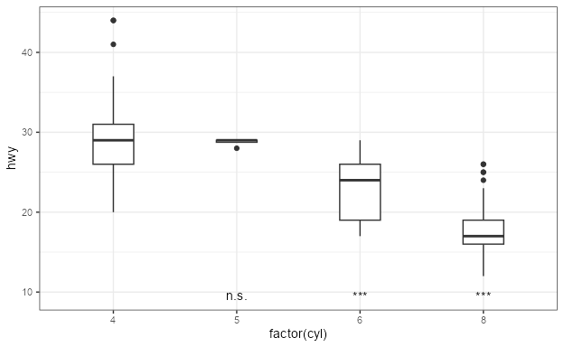

```r
ggplot(mpg, aes(factor(cyl), hwy)) +
  geom_boxplot(width = 0.33) +
  stat_multcomp(aes(x = stage(start = factor(cyl),
                              after_stat = xmax),
                    label = after_stat(stars.label)),
                geom = "text",
                label.y = "bottom",
                vstep = 0,
                contrasts = "Dunnet")
```

The returned value includes numeric and logical values in addition to character strings mapped to the `label` aesthetic. These values can be used to encode the outcomes using additional or different aesthetics than the default ones. Variable `p.signif` is `TRUE` if `p.value < mc.critical.p.value`. In this example `colour` is used to highlight significant pairwise differences based on the default critical value of 0.05.

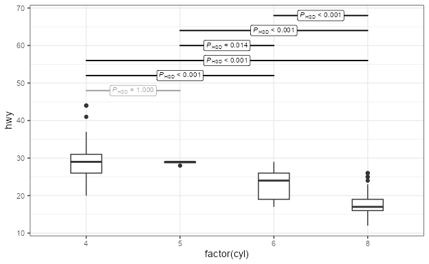

```r
ggplot(mpg, aes(factor(cyl), hwy)) +
  geom_boxplot(width = 0.33) +
  stat_multcomp(aes(colour = after_stat(p.signif)),
                size = 2.75) +
  scale_colour_manual(values = c("grey60", "black")) +
  theme_bw()
```

Alternatively, the test can be done against the `numeric` variable `p.value`. In this example `fill` is used to highlight significant pairwise differences and arrows heads added to segments.

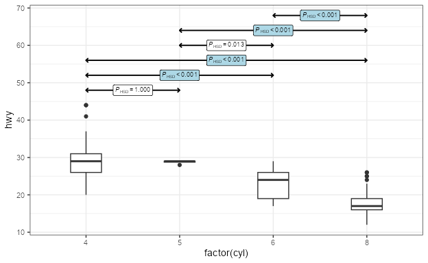

```r
ggplot(mpg, aes(factor(cyl), hwy)) +
  geom_boxplot(width = 0.33) +
  stat_multcomp(aes(fill = after_stat(p.value) < 0.01),
                size = 2.5,
                arrow = grid::arrow(angle = 45,
                                    length = unit(1, "mm"),
                                    ends = "both")) +
  scale_fill_manual(values = c("white", "lightblue"))
```

## stat_fit_residuals

Sometimes we need to quickly plot residuals matching fits plotted with `stat_poly_line()`, `stat_quant_line()`, `stat_ma_line()` or `ggplot2::stat_smooth()` (e.g., using grouping and facets). Function `stat_fit_residuals()` makes this easy. In teaching it is specially important to avoid distractions and plots residuals from different types of models consistently.

`stat_fit_residuals()` can be used to plot the residuals from models of *y* on *x* or *x* on *y* fitted with function `lm`, `MASS:rlm`, `quantreg::rq` (only median regression) or a user-supplied model fitting function and arguments. In the data frame returned by the statistic the response variable, *y* or *x*, is replaced by the residuals from the fit and thus also by default mapped to the aesthetic of the same name. The default geom is `"point"`.

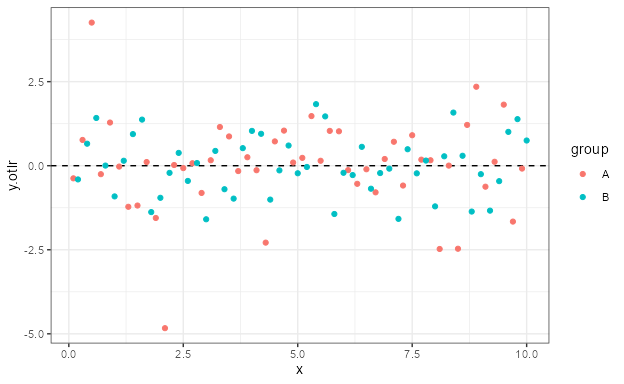

```r
ggplot(my.data, aes(x, y.otlr, colour = group)) +
  geom_hline(yintercept = 0, linetype = "dashed") +
  stat_fit_residuals()
```

Depending on the model fit `method`, two types of *weights* are available: prior weights given by a numeric variable mapped to `weight` aesthetic and posterior weights, actually used, and possibly computed during model fitting. Depending on the model fit `method`, prior and posterior weights can be the same or not. Function `stat_fit_residuals()` returns the *prior* weights supplied as input in the variable named `weights` and the posterior actually used weights, possibly computed “robustness” weights, in the variable named `posterior.weights`. Both weights can be mapped to aesthetics, in the example below `posterior.weights` are mapped to `size`. In a model fit with `lm()`, prior and posterior weights are the same, and by default equal to 1. In a fit with `rlm()` prior and posterior weights differ.

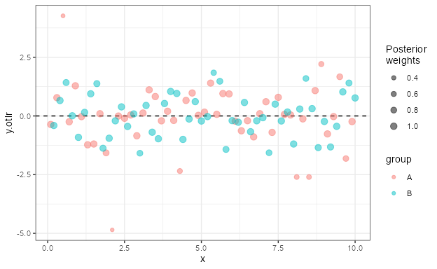

```r
ggplot(my.data, aes(x, y.otlr, colour = group)) +
  geom_hline(yintercept = 0, linetype = "dashed") +
  stat_fit_residuals(method = "rlm",
                     mapping = aes(size = after_stat(posterior.weights)),
                     alpha = 1/2) +
  scale_size_area(name = "Posterior\nweights", max_size = 3)
```

Of course it is also possible to plot the weights themselves.

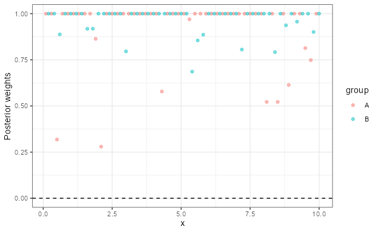

```r
ggplot(my.data, aes(x, y.otlr, colour = group)) +
  geom_hline(yintercept = 0, linetype = "dashed") +
  stat_fit_residuals(method = "rlm",
                     mapping =
                       aes(y = stage(start = y.otlr,
                                     after_stat = posterior.weights)),
                     alpha = 1/2) +
  scale_y_continuous(name = "Posterior weights")
```

Weighted residuals are available, and in this case they differ from the raw residuals as we have mapped variable `wght.otlr` to the `weight` aesthetic. Compare the two figures below.

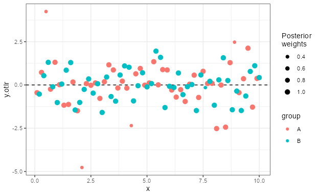

```r
ggplot(my.data, aes(x, y.otlr,
                    weight = wght.otlr,
                    colour = group)) +
  geom_hline(yintercept = 0, linetype = "dashed") +
  stat_fit_residuals(formula = formula,
                     mapping = aes(size = after_stat(posterior.weights)),
                     weighted = FALSE) +
  scale_size_area(name = "Posterior\nweights", max_size = 3)
```

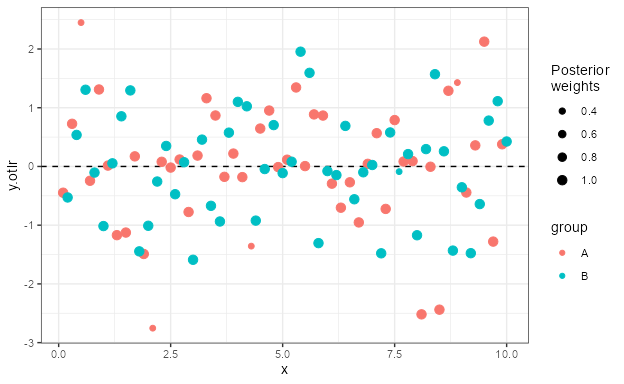

```r
ggplot(my.data, aes(x, y.otlr,
                    weight = wght.otlr,
                    colour = group)) +
  geom_hline(yintercept = 0, linetype = "dashed") +
  stat_fit_residuals(formula = formula,
                     mapping = aes(size = after_stat(posterior.weights)),
                     weighted = TRUE) +
  scale_size_area(name = "Posterior\nweights", max_size = 3)
```

## stat_fit_deviations

When teaching we may wish to highlight residuals in plots used in slides and notes. Statistic `stat_fit_deviations()` makes it easy to achieve this for the residuals from models of *y* on *x* or *x* on *y* fitted with function `lm`, `MASS:rlm`, `quantreg::rq` (only median regression) or a user-supplied model fitting function and arguments. The observed values are mapped to aesthetics *x* and *y*, and the fitted values are mapped to aesthetics *xend* and *yend*. As the default geom is `"segment"`, each deviation is displayed as a segment.

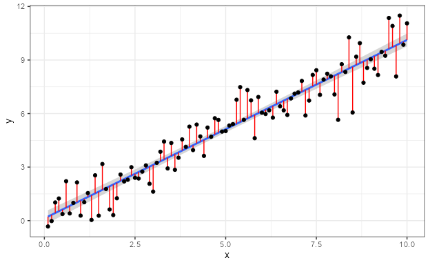

```r
ggplot(my.data, aes(x, y)) +
  stat_poly_line() +
  stat_fit_deviations(colour = "red") +
  geom_point()
```

The geometry used by default is `ggplot2::geom_segment()` and additional aesthetics can be mapped or set to constant values. Here we add arrowheads.

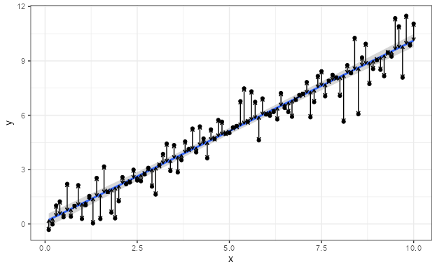

```r
ggplot(my.data, aes(x, y)) +
  stat_poly_line() +
  geom_point() +
  stat_fit_deviations(arrow = arrow(length = unit(0.015, "npc"),
                                   ends = "both"))
```

When weights are available, either supplied by the user, or computed as part of the fit, they are returned in `data`. Having weights available allows encoding them using colour. We here use a robust regression fit with `MASS::rlm()`.

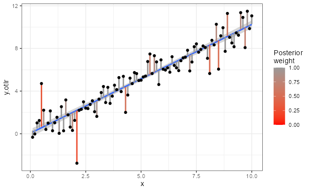

```r
ggplot(my.data, aes(x, y.otlr)) +
  stat_poly_line(method = "rlm") +
  stat_fit_deviations(formula = formula, method = "rlm",
                      mapping = aes(colour = after_stat(posterior.weights)),
                      linewidth = 1,
                      show.legend = TRUE) +
  scale_color_gradient(name = "Posterior\nweight",
                       low = "red", high = "grey60", limits = c(0, 1)) +
  geom_point()
```

With method `gls()` using `varPower()` fitted weights for heterogeneous error variance describe the change in variance as a function of the fitted values.

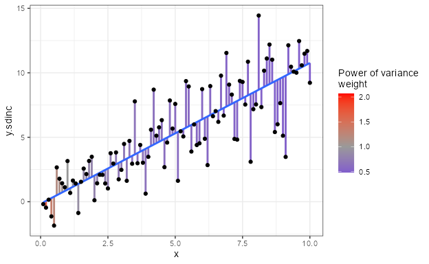

```r
ggplot(my.data, aes(x, y.sdinc)) +
  stat_fit_deviations(method = "gls",
                      method.args = list(weights = varPower(form = ~ x)),
                      mapping =
                        aes(colour = after_stat(posterior.weights)),
                      linewidth = 1,
                      show.legend = TRUE) +
  stat_poly_line(method = "gls",
                 method.args = list(weights = varPower(form = ~ x))) +
  geom_point() +
  scale_colour_gradient2(name = "Power of variance\nweight",
                         midpoint = 1, low = "blue", high = "red", mid = "grey60")
```

Of course it is also possible to plot the weights themselves, most easily using `stat_fit_residuals()`. The weights when using a variance covariate with its defaults, like here, are a function of the *predicted* values rather than of the individual deviations.

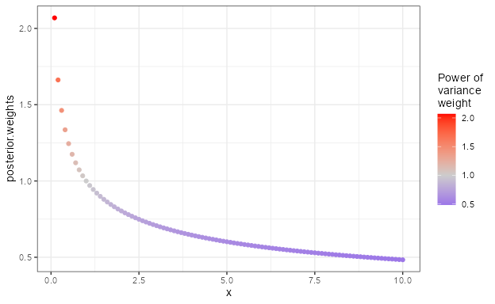

```r
ggplot(my.data, aes(x, y.sdinc)) +
  stat_fit_residuals(method = "gls",
                     method.args = list(weights = varPower(form = ~ x)),
                     geom = "point",
                     mapping =
                       aes(y = stage(start = y.sdinc,
                                     after_stat = posterior.weights),
                           colour = after_stat(posterior.weights))) +
  scale_colour_gradient2(name = "Power of\nvariance\nweight",
                         midpoint = 1, low = "blue", high = "red", mid = "grey80")
```

## stat_fit_glance

Package ‘broom’ provides consistently formatted output from different model fitting functions. These made it possible to write a model-annotation statistic that is very flexible but that requires additional input from the user to generate the character strings to be mapped to the `label` aesthetic.

As we have above given some simple examples, we here exemplify this statistic in a plot with grouping, and assemble a label for the *P*-value using a string parsed into a expression. We also change the default position of the labels.

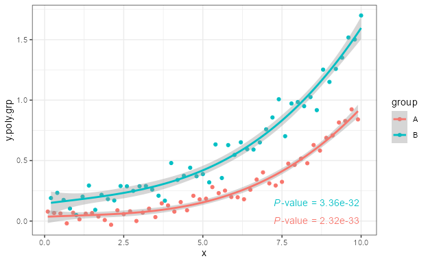

```r
# formula <- y ~ poly(x, 3, raw = TRUE)
# broom::augment does not handle poly() correctly!
formula <- y ~ x + I(x^2) + I(x^3)
ggplot(my.data, aes(x, y.poly.grp, colour = group)) +
  geom_point() +
  stat_poly_line(formula = formula) +
  stat_fit_glance(method = "lm",
                  method.args = list(formula = formula),
                  label.x = "right",
                  label.y = "bottom",
                  aes(label = sprintf("italic(P)*\"-value = \"*%.3g",
                                      after_stat(p.value))),
                  parse = TRUE)
```

It is also possible to fit a non-linear model using least squares (LS) with `method = "nls"`, and any other model for which a `broom::glance()` method exists. Do consult the documentation for package ‘broom’. Here we fit the Michaelis-Menten equation to reaction rate versus concentration data.

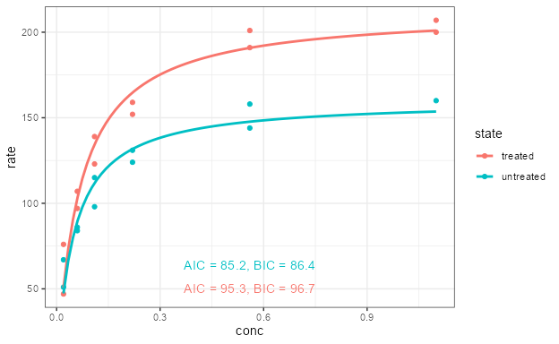

```r
micmen.formula <- y ~ SSmicmen(x, Vm, K)
ggplot(Puromycin, aes(conc, rate, colour = state)) +
  geom_point() +
  stat_smooth(method = "nls",
              formula = micmen.formula,
              se = FALSE) +
  stat_fit_glance(method = "nls",
                  method.args = list(formula = micmen.formula),
                  aes(label =
                        after_stat(
                          paste("AIC = ", signif(AIC, digits = 3),
                                ", BIC = ", signif(BIC, digits = 3),
                                sep = ""))),
                  label.x = "centre",
                  label.y = "bottom")
```

## stat_fit_tb

This ggplot statistic makes it possible to add summary or ANOVA tables for any fitted model for which `broom::tidy()` is implemented. The output from `broom::tidy()` is embedded as a single list value within the returned `data`, as an object of class `tibble::tibble`.

This statistic **ignores grouping** based on aesthetics, i.e., uses a *panel function* to fit the model. Fitting the model by panel allows fitting models when `x` or `y` is a `factor` (as in such cases `ggplot` splits the data into groups, one for each level of the factor, which is needed for example for `stat_summary()` to work as expected). By default, the `"table"` geometry is used. The use of `ggpp::geom_table()` is described in the User Guide of package ‘ggpp’. Table themes and mapped aesthetics are supported.

The default output of `stat_fit_tb()` is the default output from `tidy(fm)` where `fm` is the fitted model.

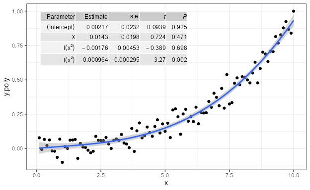

```r
formula <- y ~ x + I(x^2) + I(x^3)
ggplot(my.data, aes(x, y.poly)) +
  geom_point() +
  stat_poly_line(formula = formula) +
  stat_fit_tb(method.args = list(formula = formula),
              tb.vars = c(Parameter = "term",
                          Estimate = "estimate",
                          "s.e." = "std.error",
                          "italic(t)" = "statistic",
                          "italic(P)" = "p.value"),
              label.y = "top", label.x = "left",
              parse = TRUE)
```

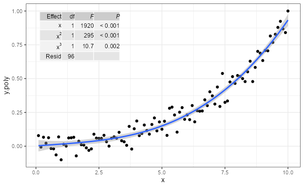

```r
formula <- y ~ x + I(x^2) + I(x^3)
ggplot(my.data, aes(x, y.poly)) +
  geom_point() +
  stat_poly_line(formula = formula) +
  stat_fit_tb(method.args = list(formula = formula),
              tb.type = "fit.anova",
              tb.vars = c(Effect = "term",
                          df = "df",
                          "italic(F)" = "statistic",
                          "italic(P)" = "p.value"),
              tb.params = c(x = 1, "x^2" = 2, "x^3" = 3, Resid = 4),
              label.y = "top", label.x = "left",
              parse = TRUE)
```

When `tb.type = "fit.coefs"` the output returned is that of `tidy(fm)` after selecting the `term` and `estimate` columns.

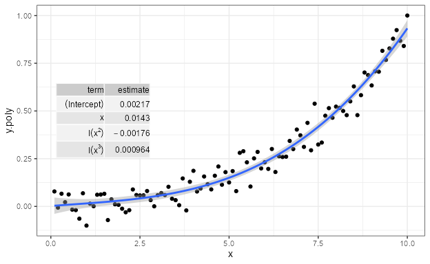

```r
formula <- y ~ x + I(x^2) + I(x^3)
ggplot(my.data, aes(x, y.poly)) +
  geom_point() +
  stat_poly_line(method = "lm", formula = formula) +
  stat_fit_tb(method = "lm",
              method.args = list(formula = formula),
              tb.type = "fit.coefs", parse = TRUE,
              label.y = "center", label.x = "left")
```

Faceting works as expected, but grouping is ignored as mentioned above. In this case, the colour aesthetic is not applied to the text of the tables. Furthermore, if `label.x.npc` or `label.y.npc` are passed numeric vectors of length > 1, the corresponding values are obeyed by the different panels.

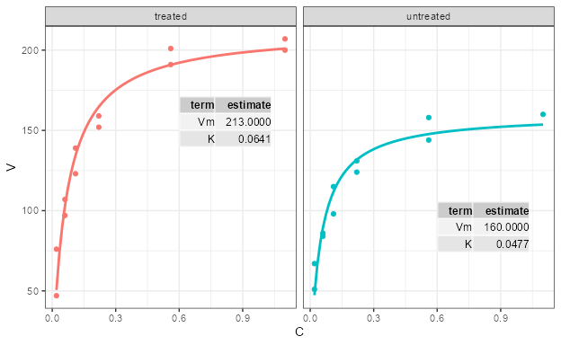

```r
micmen.formula <- y ~ SSmicmen(x, Vm, K)
ggplot(Puromycin, aes(conc, rate, colour = state)) +
  facet_wrap(~state) +
  geom_point() +
  stat_smooth(method = "nls",
              formula = micmen.formula,
              se = FALSE) +
  stat_fit_tb(method = "nls",
              method.args = list(formula = micmen.formula),
              tb.type = "fit.coefs",
              label.x = 0.9,
              label.y = c(0.75, 0.2)) +
  theme(legend.position = "none") +
  labs(x = "C", y = "V")
```

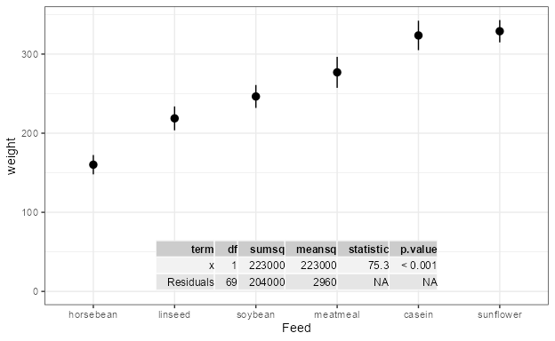

```r
ggplot(chickwts, aes(reorder(factor(feed), weight), weight)) +
  stat_summary(fun.data = "mean_se") +
  stat_fit_tb(tb.type = "fit.anova",
              label.x = "center",
              label.y = "bottom") +
  labs(x = "Feed") +
  expand_limits(y = 0)
```

We can flip the system of coordinates, if desired.

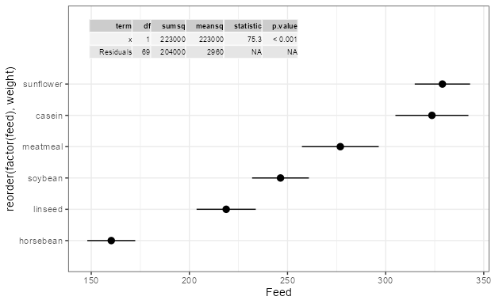

```r
ggplot(chickwts, aes(reorder(factor(feed), weight), weight)) +
  stat_summary(fun.data = "mean_se") +
  stat_fit_tb(tb.type = "fit.anova", label.x = "left", size = 3) +
  scale_x_discrete(expand = expansion(mult = c(0.2, 0.5))) +
  labs(y = "Feed") +
  coord_flip()
```

It is also possible to rotate the table using `angle`. Here we also show how to replace the column headers with strings to be parsed into R expressions.

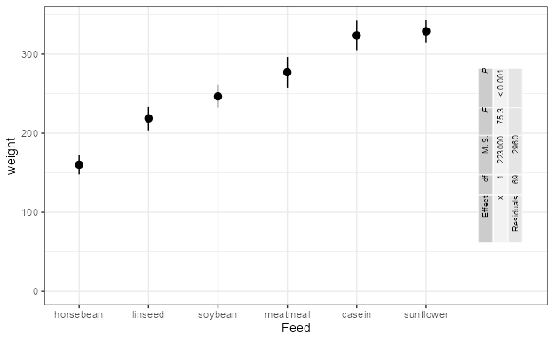

```r
ggplot(chickwts, aes(reorder(factor(feed), weight), weight)) +
  stat_summary(fun.data = "mean_se") +
  stat_fit_tb(tb.type = "fit.anova",
              angle = 90, size = 3,
              label.x = "right", label.y = "center",
              hjust = 0.5, vjust = 0,
              tb.vars = c(Effect = "term",
                          "df",
                          "M.S." = "meansq",
                          "italic(F)" = "statistic",
                          "italic(P)" = "p.value"),
              parse = TRUE) +
  scale_x_discrete(name = "Feed",
                   expand = expansion(mult = c(0.1, 0.35))) +
  expand_limits(y = 0)
```

## stat_fit_tidy

This stat makes it possible to add the equation for any fitted model for which `broom::tidy()` is implemented. Alternatively, individual values such as estimates for the fitted parameters, standard errors, or *P*-values can be added to a plot. However, the user has to explicitly construct the labels within `ggplot2::aes()`. This statistic respects grouping based on aesthetics, and reshapes the output of `broom::tidy()` so that the values for a given group are in a single row in the returned `data`.

As first example we fit a non-linear model, the Michaelis-Menten equation of reaction kinetics, using `stats::nls()`. We use the self-starting function `stats::SSmicmen()` available in R.

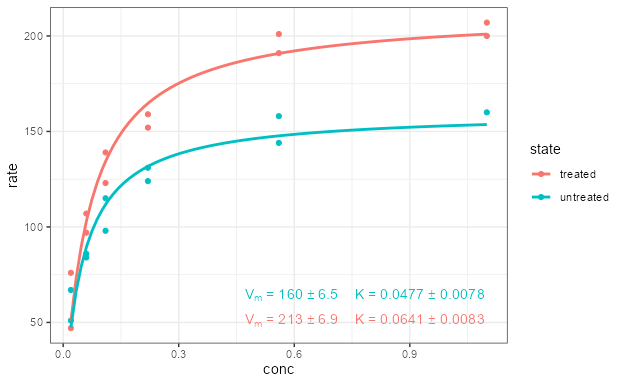

```r
micmen.formula <- y ~ SSmicmen(x, Vm, K)
ggplot(Puromycin, aes(conc, rate, colour = state)) +
  geom_point() +
  stat_smooth(method = "nls",
              formula = micmen.formula,
              se = FALSE) +
  stat_fit_tidy(method = "nls",
                method.args = list(formula = micmen.formula),
                label.x = "right",
                label.y = "bottom",
                aes(label =
                      after_stat(
                        paste("V[m]~`=`~", signif(Vm_estimate, digits = 3),
                              "%+-%", signif(Vm_se, digits = 2),
                              "~~~~K~`=`~", signif(K_estimate, digits = 3),
                              "%+-%", signif(K_se, digits = 2),
                              sep = ""))),
                parse = TRUE)
```

Using paste we can build a string that can be parsed into an R expression, in this case for a non-linear equation.

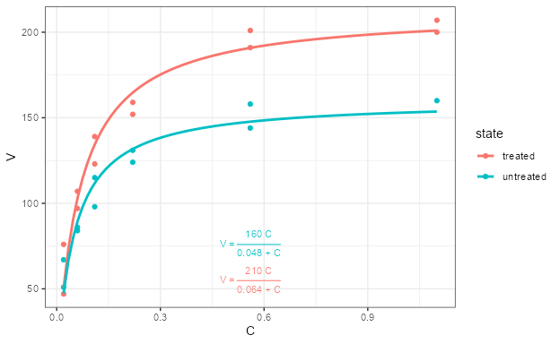

```r
micmen.formula <- y ~ SSmicmen(x, Vm, K)
ggplot(Puromycin, aes(conc, rate, colour = state)) +
  geom_point() +
  stat_smooth(method = "nls",
              formula = micmen.formula,
              se = FALSE) +
  stat_fit_tidy(method = "nls",
                method.args = list(formula = micmen.formula),
                size = 3,
                label.x = "center",
                label.y = "bottom",
                vstep = 0.12,
                aes(label =
                      after_stat(
                        paste("V~`=`~frac(",
                              signif(Vm_estimate, digits = 2), "~C,",
                              signif(K_estimate, digits = 2), "+C)",
                              sep = ""))),
                parse = TRUE) +
  labs(x = "C", y = "V")
```

What if we would need a more specific *statistic*, similar to `stat_poly_eq()`? We can use `stat_fit_tidy()` as the basis for its definition.

```r
stat_micmen_eq <- function(vstep = 0.12,
                           size = 3,
                           ...) {
  stat_fit_tidy(method = "nls",
                method.args = list(formula = micmen.formula),
                aes(label =
                      after_stat(
                        paste("V~`=`~frac(",
                              signif(Vm_estimate, digits = 2), "~C,",
                              signif(K_estimate, digits = 2), "+C)",
                              sep = ""))),
                parse = TRUE,
                vstep = vstep,
                size = size,
                ...)
}
```

The code for the figure is now simpler, and still produces the same figure (not shown).

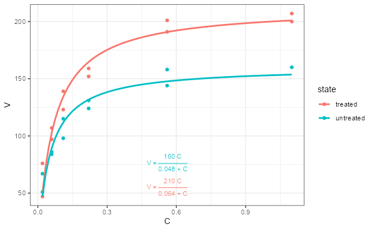

```r
micmen.formula <- y ~ SSmicmen(x, Vm, K)
ggplot(Puromycin, aes(conc, rate, colour = state)) +
  geom_point() +
  stat_smooth(method = "nls",
              formula = micmen.formula,
              se = FALSE) +
  stat_micmen_eq(label.x = "center",
                label.y = "bottom") +
  labs(x = "C", y = "V")
```

- As a second example we show a quantile regression fit using function `quantreg::rq()` from package ‘quantreg’.

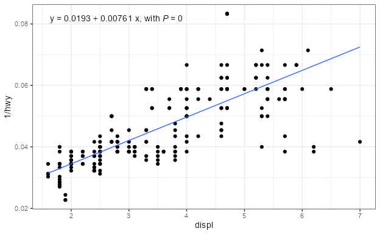

```r
my_formula <- y ~ x
my.format <- 'y~"="~%.3g+%.3g~x*", with "*italic(P)~"="~%.3f'
ggplot(mpg, aes(displ, 1 / hwy)) +
  geom_point() +
  stat_quantile(quantiles = 0.5, formula = my_formula) +
  stat_fit_tidy(method = "rq",
                method.args = list(formula = y ~ x, tau = 0.5),
                tidy.args = list(se.type = "nid"),
                mapping = aes(label =
                                after_stat(
                                  sprintf(fmt = my.format,
                                          Intercept_estimate,
                                          x_estimate,
                                          x_p.value))),
                parse = TRUE)
```

We can define a `stat_rq_eq()` if we need to add similar equations to several plots. In this example we retain the ability of the user to override most of the default default arguments.

```r
stat_rq_eqn <-
  function(formula = y ~ x,
           tau = 0.5,
           method = "br",
           mapping =
             aes(label =
                   after_stat(
                     sprintf(
                       'y~"="~%.3g+%.3g~x*", with "*italic(P)~"="~%.3f',
                       Intercept_estimate, x_estimate, x_p.value))),
           parse = TRUE,
           ...) {
    method.args <- list(formula = formula,
                        tau = tau,
                        method = method)
    stat_fit_tidy(method = "rq",
                  method.args = method.args,
                  tidy.args = list(se.type = "nid"),
                  mapping = mapping,
                  parse = parse,
                  ...)
  }
```

And the code of the figure now as simple as. Figure not shown, as is identical to the one above.

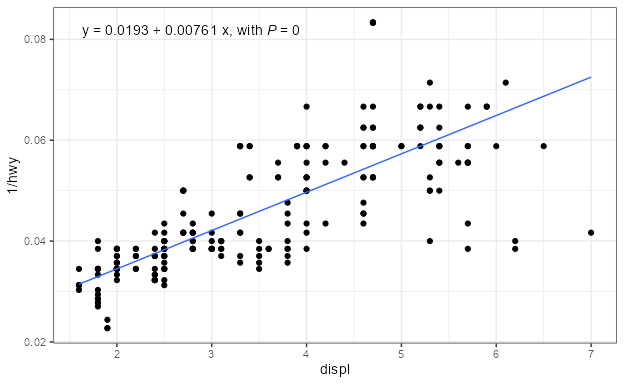

```r
ggplot(mpg, aes(displ, 1 / hwy)) +
  geom_point() +
  stat_quantile(quantiles = 0.5, formula = my_formula) +
  stat_rq_eqn(tau = 0.5, formula = my_formula)
```

## stat_fit_augment

Use `ggplot2::stat_smooth`, `stat_poly_line()`, `stat_ma_line()`, `stat_quant_line()`, `stat_deviations()` or `stat_residuals()` instead of `stat_fit_augment` if possible.

When statistics specific to the type of model fitted are available, their use is in general simpler that the use of `stat_fit_augment()`. On the other hand, `stat_fit_augment()` can handle any fitted model that is supported by package ‘broom’ or its extensions. All these statistics support grouping and facets.

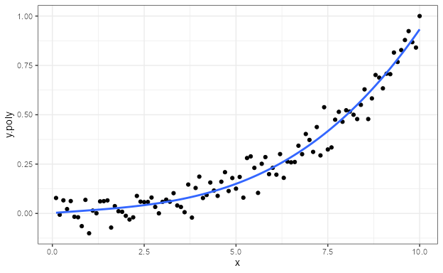

```r
# formula <- y ~ poly(x, 3, raw = TRUE)
# broom::augment does not handle poly correctly!
formula <- y ~ x + I(x^2) + I(x^3)
ggplot(my.data, aes(x, y.poly)) +
  geom_point() +
  stat_fit_augment(method = "lm",
                   method.args = list(formula = formula))
```

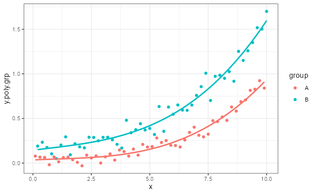

```r
formula <- y ~ x + I(x^2) + I(x^3)
ggplot(my.data, aes(x, y.poly.grp, colour = group)) +
  geom_point() +
  stat_fit_augment(method = "lm",
                   method.args = list(formula = formula))
```

We can override the variable returned as `y` to be any of the variables in the data frame returned by `broom::augment()` while still preserving the original `y` values.

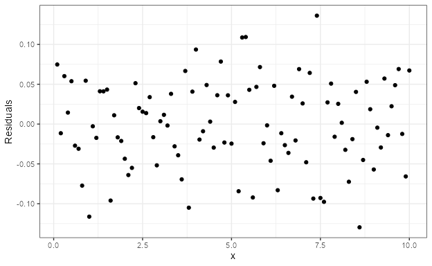

```r
formula <- y ~ x + I(x^2) + I(x^3)
ggplot(my.data, aes(x, y.poly)) +
  stat_fit_augment(method = "lm",
                   method.args = list(formula = formula),
                   geom = "point",
                   y.out = ".resid") +
  labs(y = "Residuals")
```

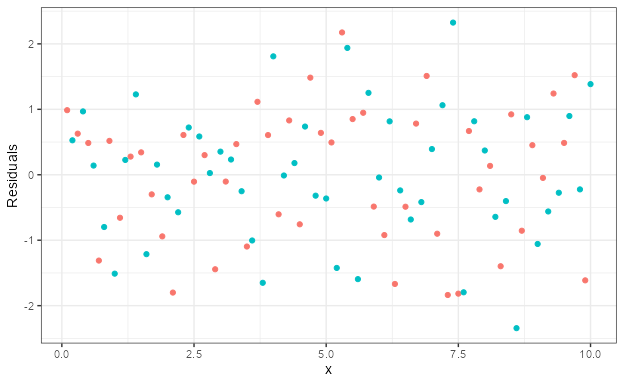

```r
formula <- y ~ x + I(x^2) + I(x^3)
ggplot(my.data, aes(x, y.poly.grp, colour = group)) +
  stat_fit_augment(method = "lm",
                   method.args = list(formula = formula),
                   geom = "point",
                   y.out = ".std.resid") +
  labs(y = "Residuals")
```

We can use any model fitting method for which `broom::augment()` is implemented. *When a method, in this case of `nls()`, has no support for confidence limits and ‘broom’ sets them to `NA` values, no confidence band in plotted and a warning is issued by `geom_smooth()` from ‘ggplot2’, which is the default. The warning is harmless, and if needed, it can be silenced by passing `geom = "line"` to override the default.*

```
## Warning in max(ids, na.rm = TRUE): no non-missing arguments to max; returning
## -Inf
```

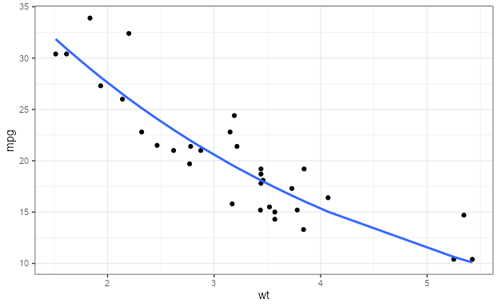

```r
args <- list(formula = y ~ k * e ^ x,
             start = list(k = 1, e = 2))
ggplot(mtcars, aes(wt, mpg)) +
  geom_point() +
  stat_fit_augment(method = "nls",
                   method.args = args)
```

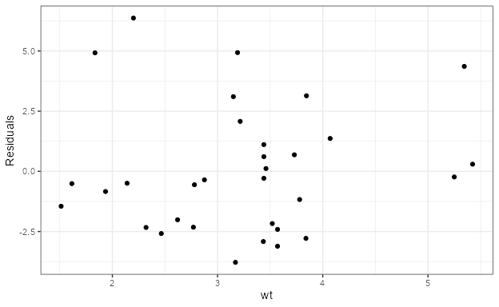

```r
args <- list(formula = y ~ k * e ^ x,
             start = list(k = 1, e = 2))
ggplot(mtcars, aes(wt, mpg)) +
  stat_fit_augment(method = "nls",
                   method.args = args,
                   geom = "point",
                   y.out = ".resid") +
  labs(y = "Residuals")
```

**Note:** The tidiers for mixed models have moved to package ‘broom.mixed’!

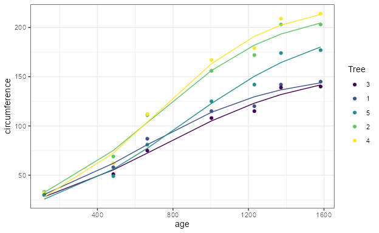

```r
args <- list(model = y ~ SSlogis(x, Asym, xmid, scal),
             fixed = Asym + xmid + scal ~1,
             random = Asym ~1 | group,
             start = c(Asym = 200, xmid = 725, scal = 350))
ggplot(Orange, aes(age, circumference, colour = Tree)) +
  geom_point() +
  stat_fit_augment(method = "nlme",
                   method.args = args,
                   augment.args = list(data = quote(data)),
                   geom = "line")
```

## Inspecting computed variables and labels

In the case of model fitting statistics like `stat_poly_eq()` and `stat_poly_line()`, which variables are present or are not set to `NA` depends on the model fit `method` used and frequently also on the arguments passed to the parameters of the stats including method `method.args`.

In ‘ggpmisc’ (>= 1.0.0) when executed in an *interactive* R session statistics display by default a message listing either the names of variables in the returned data frame containing non-missing (tested with `is.na()`) data or the short names of non-missing formatted character strings. The messages also display the number of rows returned by compute function, per data group or per panel. In the case of column names, they can be mapped to any aesthetics using `aes()`, or to the `label` aesthetic using `use_label()` or `f_use_label()`. Functions `use_label()` or `f_use_label()` recognize short names or *nicknames* for the formatted text labels.

As other messages in R, these messages can be silenced. They can also be controlled specifically using R option `"ggpmisc.stat.vars.message"` which can take values `"colnames"`, `"nicknames"` and `"skip"`. As the documentation is generated in an R session that is not interactive, the option needs to be set here to display a message.

```r
# force same behavious as in an interactive R session
old.options <- options(ggpmisc.stat.vars.message = "nicknames")
```

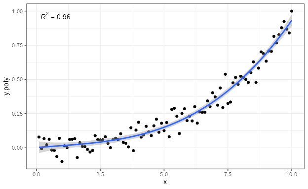

```r
formula <- y ~ poly(x, 3, raw = TRUE)
ggplot(my.data, aes(x, y.poly)) +
  geom_point() +
  stat_poly_line(formula = formula) +
  stat_poly_eq(formula = formula)
```

Moreover, when using `stat_fit_glance()`, `stat_fit_tidy()`, `stat_fit_augment()` and `stat_fit_tb()` the documentation cannot describe the variables present in the returned `data` because they call methods using their generic interface and the exact specialization used depends on the argument passed to `method`, which can be easily be one that has not been tested during the development of ‘ggpmisc’. These statistics do not automatically generate formatted labels and the message lists all columns in the returned data frame containing available data.

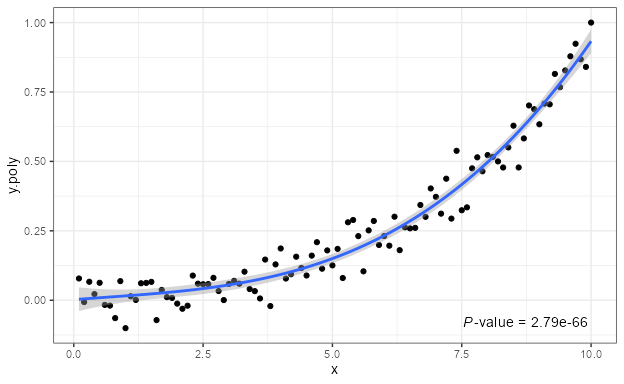

```r
# formula <- y ~ poly(x, 3, raw = TRUE)
# broom::augment does not handle poly() correctly
formula <- y ~ x + I(x^2) + I(x^3)
ggplot(my.data, aes(x, y.poly)) +
  geom_point() +
  stat_poly_line(formula = formula) +
  stat_fit_glance(aes(label =
                        after_stat(
                          sprintf("italic(P)*\"-value = \"*%.3g",
                                  p.value))),
                  parse = TRUE,
                  method.args = list(formula = formula),
                  label.x = "right",
                  label.y = "bottom")
```

We restore the options to their previous state.

```r
options(old.options)
```

In addition package ‘gginnards’ exports `gginnards::geom_debug_group()` that prints the data frame, making it possible to explore its contents by temporarily substituting other geoms with in the plot code.

`gginnards::geom_debug_group()` uses by default `head()` to echo to the R console the data it receives as input. It ignores the aesthetic mappings so it can be used with any statistics or directly as a layer function. However, unrecognised aesthetics can trigger warnings during plot rendering. These warnings can be ignored in most cases.

```
## Warning: Computation failed in `stat_fit_glance()`.
## Caused by error in `scales$flipped_names()`:
## ! attempt to apply non-function
```

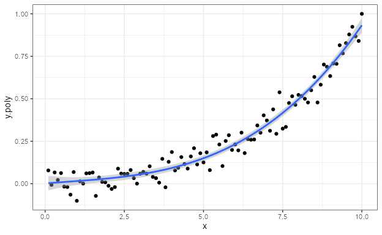

```r
# formula <- y ~ poly(x, 3, raw = TRUE)
# broom::augment does not handle poly() correctly!
formula <- y ~ x + I(x^2) + I(x^3)
ggplot(my.data, aes(x, y.poly)) +
  geom_point() +
  stat_poly_line(formula = formula) +
  stat_fit_glance(aes(label =
                        after_stat(
                          sprintf("italic(P)*\"-value = \"*%.3g",
                                  p.value))),
#                  parse = TRUE,
                  geom = "debug_group",
                  method.args = list(formula = formula),
                  label.x = "right",
                  label.y = "bottom")
```

In the case of `stat_fit_tb()` the computed variables returned include a list column containing embedded data frames. In this case, function `str()` is more informative than `head()`, so we can pass it as argument overriding the default.

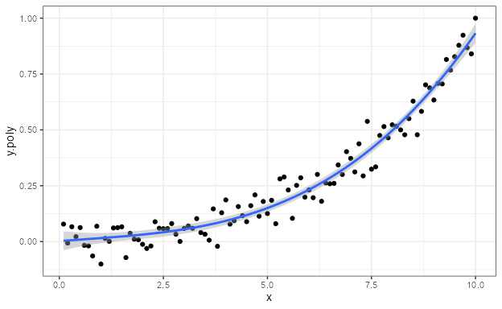

```r
formula <- y ~ x + I(x^2) + I(x^3)
ggplot(my.data, aes(x, y.poly)) +
  geom_point() +
  stat_poly_line(formula = formula) +
  stat_fit_tb(geom = "debug_panel",
              summary.fun = str,
              method.args = list(formula = formula),
              tb.vars = c(Parameter = "term",
                          Estimate = "estimate",
                          "s.e." = "std.error",
                          "italic(t)" = "statistic",
                          "italic(P)" = "p.value"),
#              parse = TRUE,
              label.y = "top",
              label.x = "left")
```

`gginnards::geom_debug_group()` can be used with stats from ‘ggplot2’ and its extensions. More examples are given in the [documentation of package ‘gginnards’](https://docs.r4photobiology.info/gginnards/).

# Examples for Scales

Volcano and quadrant plots are scatter plots with some peculiarities. Creating these plots from scratch using ‘ggplot2’ can be time consuming, but allows flexibility in design. Rather than providing a ‘canned’ function to produce volcano plots, package ‘ggpmisc’ provides several building blocks that facilitate the production of volcano and quadrant plots. These are wrappers on *scales* from packages ‘scales’ and ‘ggplot2’ with suitable defaults plus helper functions to create factors from numeric outcomes.

## scale_color_outcome, scale_fill_outcome

Manual scales for colour and fill aesthetics with defaults suitable for the three way outcomes from statistical tests.

## scale_x_FDR, scale_y_FDR, scale_x_logFC, scale_y_logFC, scale_x_Pvalue, scale_y_Pvalue

Scales for *x* or *y* aesthetics mapped to *P*-values, FDR (false discovery rate) or log FC (logarithm of fold-change) as used in volcano and quadrant plots of transcriptomics and metabolomics data.

## symmetric_limits

A simple function to expand scale limits to be symmetric around zero. Can be passed as argument to parameter limits of continuous scales from packages ‘ggpmisc’, ‘ggplot2’ or ‘scales’ (and extensions).

## Volcano-plot examples

Volcano plots are frequently used for transcriptomics and metabolomics. They are used to show *P*-values or FDR (false discovery rate) as a function of effect size, which can be either an increase or a decrease. Effect sizes are expressed as fold-changes compared to a control or reference condition. Colours are frequently used to highlight significant responses. Counts of significant increases and decreases are frequently also added.

Outcomes encoded as -1, 0 or 1, as seen in the tibble below need to be converted into factors with suitable labels for levels. This can be easily achieved with function `outcome2factor()`.

```r
head(volcano_example.df)
```

```
##         tag     gene outcome       logFC     PValue genotype
## 1 AT1G01040     ASU1       0 -0.15284466 0.35266997      Ler
## 2 AT1G01290     ASG4       0 -0.30057068 0.05471732      Ler
## 3 AT1G01560 ATSBT1.1       0 -0.57783350 0.06681310      Ler
## 4 AT1G01790   AtSAM1       0 -0.04729662 0.74054263      Ler
## 5 AT1G02130  AtTRM82       0 -0.14279891 0.29597519      Ler
## 6 AT1G02560    PRP39       0  0.23320752 0.07487043      Ler
```

Most frequently fold-change data is available log-transformed, using either 2 or 10 as base. In general it is more informative to use tick labels expressed as un-transformed fold-change.

By default `scale_x_logFC()` and `scale_y_logFC()` expect the logFC data log2-transformed, but this can be overridden. The default use of untransformed fold-change for tick labels can also be overridden. Scale `scale_x_logFC()` in addition by default expands the scale limits to make them symmetric around zero. If `%unit` is included in the name character string, suitable units are appended as shown in the example below.

Scales `scale_y_Pvalue()` and `scale_x_Pvalue()` have suitable defaults for name and labels, while `scale_colour_outcome()` provides suitable defaults for the colours mapped to the outcomes. To change the labels and title of the `key` or `guide` pass suitable arguments to parameters `name` and `labels` of these scales. These x and y scales by default *squish* off-limits (out-of-bounds) observations towards the limits.

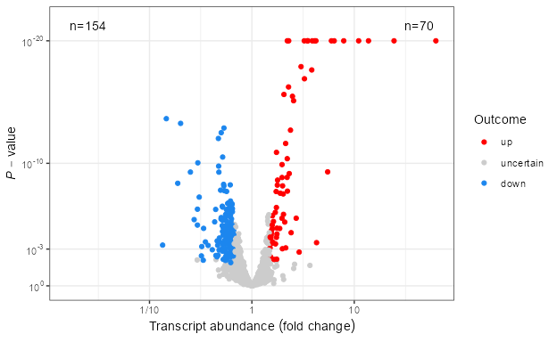

```r
ggplot(volcano_example.df,
       aes(logFC, PValue, colour = outcome2factor(outcome))) +
  geom_point() +
  scale_x_logFC(name = "Transcript abundance%unit") +
  scale_y_Pvalue() +
  scale_colour_outcome() +
  stat_quadrant_counts(data = function(x) {subset(x, outcome != 0)})
```

By default `outcome2factor()` creates a factor with three levels as in the example above, but this default can be overridden as shown below. A scale with base-two logarithms as tick labels for log FC is also used.

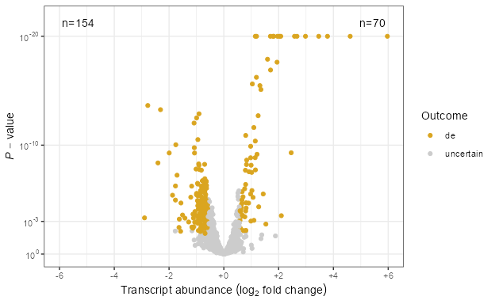

```r
ggplot(volcano_example.df,
       aes(logFC, PValue, colour = outcome2factor(outcome, n.levels = 2))) +
  geom_point() +
  scale_x_logFC(name = "Transcript abundance%unit", log.base.labels = 2) +
  scale_y_Pvalue() +
  scale_colour_outcome(values = "outcome:de") +
  stat_quadrant_counts(data = function(x) {subset(x, outcome != 0)})
```